# PostGIS vs geoParquet spatial join

Author

Jens Åström

# Intro

Researchers in Nina often want to do get areal statistics for a particular locality, or a set of localities. The underlying map to query can be large, e.g. the whole country. The task is then to make a spatial join on this large layer and smaller polygon, provided by the user. This can be a non-trivial task for many people, and it can make sense to create some software to make it more convenient, for map layers of general interest.

In particular, we are here testing the new “Grunnkart for arealregnskap”, which will be a standard resource in Norway over many years to come.

I will here test out two approaches, 1) importing the large GIS-layer to PostGIS, create and index, and later let the database do the spatial join with an arbitrary smaller layer, and 2) store the large file as a geoParquet file and do the join directly there.

```r
suppressPackageStartupMessages({
require(NinaR)
require(Norimon)
require(tidyr)
require(dplyr)
require(DBI)
require(sf)
require(ggplot2)
})
```

## Create test data

We create 2 small polygons that we can test a spatial join (clip) with.

```r
library(NinaR)
postgreSQLConnect()
require(sf)
require(dplyr)
small_sf <- tibble(locality = c("Semi-nat_99", "Semi-nat_100"), geom = c("POLYGON ((1082500 7775000, 1082500 7775500, 1083000 7775500, 1083000 7775000, 1082500 7775000))", "POLYGON ((1019000 7842500, 1019000 7843000, 1019500 7843000, 1019500 7842500, 1019000 7842500))")) |>
  st_as_sf(wkt = "geom", crs = 25833)
```

Clip the layer using PostGIS. I’ve packaged this in the function `clip_gis_layer()`. It is basically this sql-query that does the job:

```sql
SELECT tt.id as mask_id, --data_columns_of_interest_here--
ST_Intersection(t.geom_valid, tt.geom) as geom
FROM schema.layer_to_clip AS t,
temp_mask_to_intersect as tt
WHERE ST_Intersects(t.geom_valid, tt.geom)
```

```r
system.time({
small_sf_grunnkart <- clip_gis_layer(small_sf)
})
```

```
   user  system elapsed
  0.112   0.005   0.252
```

Plot one of the areas. In these examples, we use ‘ekosystemtype_1’ as the main feature to analyze, but you could choose any other as well.

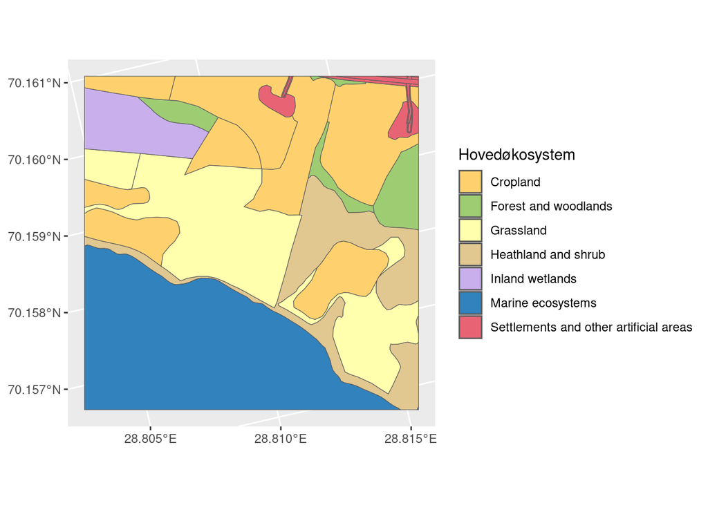

Figure 1: Ecosystem level 1 for clipped polygon

```r
small_sf_grunnkart |>
  filter(locality == "Semi-nat_100") |>
  ggplot() +
  geom_sf(aes(fill = okosystemtype_1)) +
  scale_fill_okosystemtype_1(name = "Hovedøkosystem")
```

Notice we use a custom ggplot fill function for okoystemtype_1. You can plot arealdekke in a similar way. Other color scale functions might be added later on.

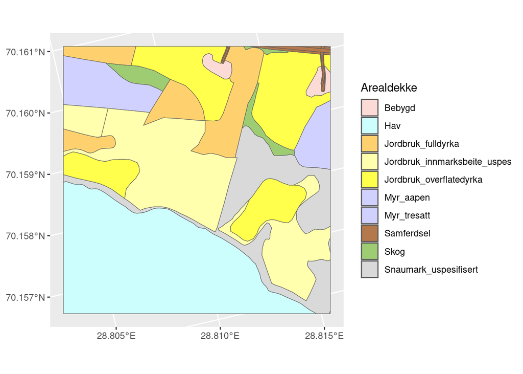

Figure 2: Arealdekke for clipped polygon

```r
small_sf_grunnkart |>
  filter(locality == "Semi-nat_100") |>
  ggplot() +
  geom_sf(aes(fill = arealdekke)) +
  scale_fill_arealdekke(name = "Arealdekke")
```

## GeoParquet way

I will use a subset of the data for now, since we don’t have a single layer for the whole thing yet.

```r
suppressPackageStartupMessages({
library(sf)
library(sfarrow)
library(geoarrow)
library(arrow)
})
```

```r
geoparquet_file_path <- "/data/R/GeoSpatialData/LandUse/Norway_Arealregnskap/Converted/56_25835_arealregnskap_gdb.parquet"


parquet_open <- open_dataset(geoparquet_file_path) |>
  st_as_sf(crs = 25835)
```

```r
small_sf <- tibble(locality = c("Semi-nat_99", "Semi-nat_100"), geom = c("POLYGON ((1082500 7775000, 1082500 7775500, 1083000 7775500, 1083000 7775000, 1082500 7775000))", "POLYGON ((1019000 7842500, 1019000 7843000, 1019500 7843000, 1019500 7842500, 1019000 7842500))")) |>
  st_as_sf(wkt = "geom", crs = 25833)

small_sf_35 <- small_sf |>
  st_transform(crs = st_crs(25835))
```

```r
#st_crs(parquet_open)
#st_crs(small_sf)

system.time({
parquet_clipped <- parquet_open |>
  st_intersection(small_sf_35)
})
```

```
   user  system elapsed
  9.286   1.230  10.516
```

This works, but takes considerably more time than querying the PostGIS database. Also, this needs to be tested on a dataset covering the whole of Norway to make a fair comparison. To be continued…

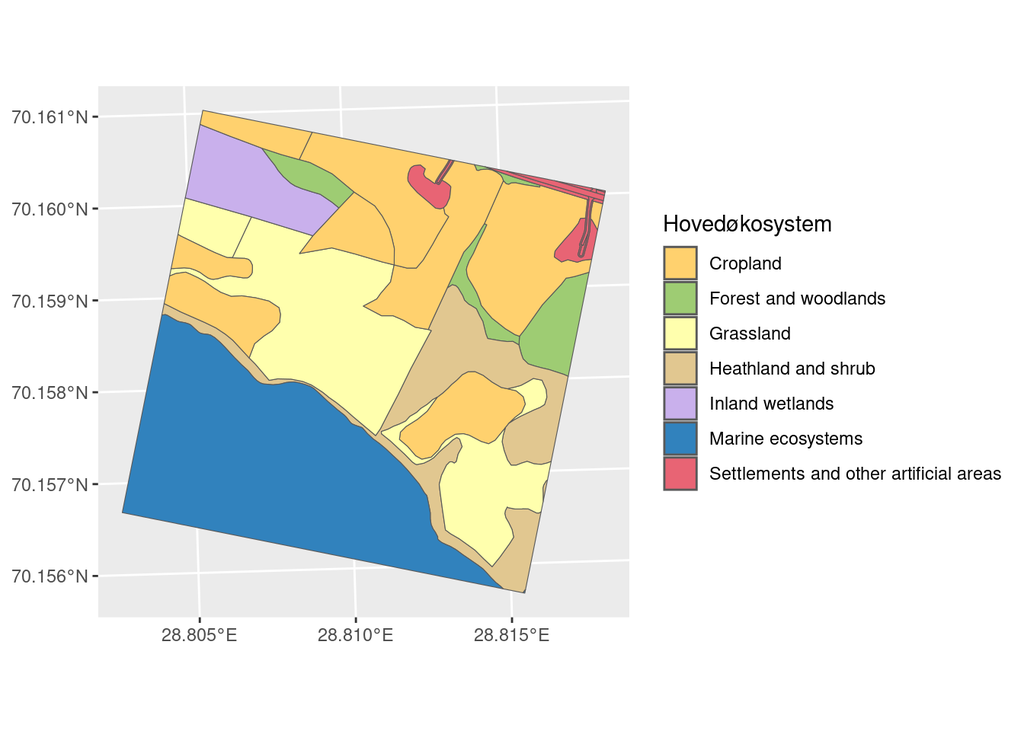

Figure 3: Ecosystem level 1 for clipped polygon

```r
parquet_clipped |>
  filter(locality == "Semi-nat_100") |>
  ggplot() +
  geom_sf(aes(fill = okosystemtype_1)) +
  scale_fill_okosystemtype_1(name = "Hovedøkosystem")
```